# DSTI - Survival Analysis Project

Samd Guizani

2026-04-17

# Imports

```r
library(tidyverse)
library(tidyr)
library(broom)
library(survival) # Survival analysis toolbox
library(gtsummary)
library(ggfortify)
library(ggsurvfit)
library(survminer) # For survival analysis plots
library(gridExtra)
library(muhaz) # Hazard function estimation
library(plyr) # For data manipulation in survival analysis
```

# Main Script

## Data Loading & Preprocessing

- `NewSpring.csv` is a publicly available dataset from *William Q. Meeker, Luis A. Escobar, Francis G. Pascual, **Statistical Methods for Reliability Data, 2nd Edition*** ([Statistical Methods for Reliability Data, 2nd Edition | Wiley](https://www.wiley.com/en-us/Statistical+Methods+for+Reliability+Data%2C+2nd+Edition-p-9781118115459))
- The file, among other datasets focusing on survival and reliability analysis, are available on *DataShare, Iowa State University’s open data repository* ([Item - Reliability Data: Laboratory Failure-Time and Single-Time Strength Data - Iowa State University - Figshare](https://iastate.figshare.com/articles/dataset/Reliability_Data_Laboratory_Failure-Time_and_Single-Time_Strength_Data/14454753?file=28383774))
- The dataset records the *number of cycles to failure* for a spring under different conditions, including:
  - *Stroke length* (factor A, numeric, 50 to 70 mils)
  - *Processing temperature* (factor B, numeric 500 to 1000 F)
  - *Method used* (factor C, categorical, New vs. Old)
- The experiment is organized as a **Full Factorial Design**. For each combination of the 3 factors, 9 units are tested for a maximum of 5000 cycles. The `Censoring` column indicates whether the observation is censored (0, the spring survived 5000 cycles) or an event (1, number of cycles until failure is recorded)
- The `Count` column represents the number of occurrences for each combination of conditions reaching an identical outcome.  
  *E.g.: a row where Censoring = 0 (Censored) and Count = 3 means 3 units reached the study end (5000 cycles) and removed from the test while still functioning.*

```r
# Import data from folder Datasets
df <- read.csv("./Datasets/NewSpring.csv")

# Rename columns for better readability
colnames(df) = c('Cycles', 'A.Stroke', 'B.ProcessTpt', 'C.Method', 'Censoring', 'Count')
factor_names = colnames(df)[2:4]

# Uncount the data by replicating rows according to the 'Count' column
df <- df |> uncount(Count)

# Convert Method to factor
df$C.Method <- as.factor(df$C.Method)
df$C.Method <- relevel(df$C.Method, ref = "Old" ) # "Old" considered as reference
```

## Exploratory Data Analysis

### Summary tables and basic plots

```r
# Convert Censoring 0 (for censored) and 1 (for failure event)
df$Censoring <- ifelse(df$Censoring == "Failed", 1, 0)
table(df$Censoring)
```

```
##
##  0  1
## 35 73
```

```r
# Data summary
summary(df)
```

```
##      Cycles        A.Stroke   B.ProcessTpt  C.Method   Censoring
##  Min.   :  89   Min.   :50   Min.   : 500   Old:54   Min.   :0.0000
##  1st Qu.:1209   1st Qu.:50   1st Qu.: 500   New:54   1st Qu.:0.0000
##  Median :2814   Median :60   Median : 750            Median :1.0000
##  Mean   :2898   Mean   :60   Mean   : 750            Mean   :0.6759
##  3rd Qu.:5000   3rd Qu.:70   3rd Qu.:1000            3rd Qu.:1.0000
##  Max.   :5000   Max.   :70   Max.   :1000            Max.   :1.0000
```

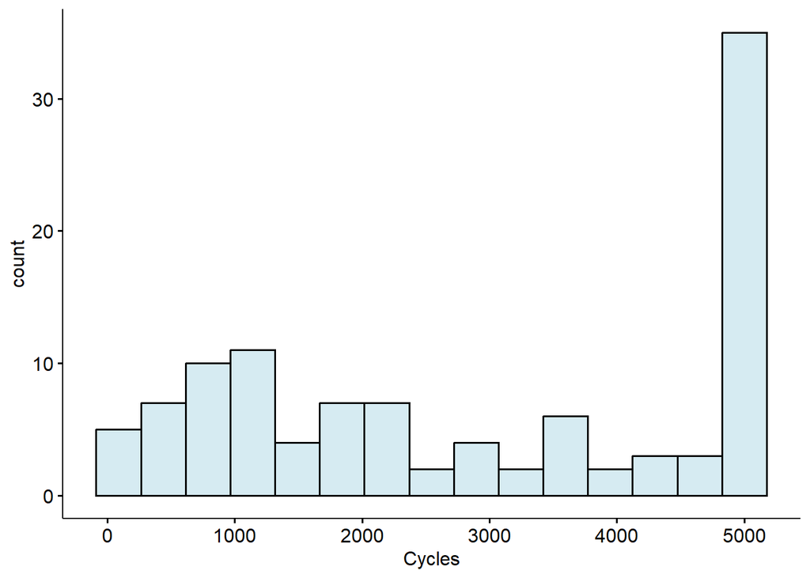

```r
# Histogram of Cycles
gghistogram(df, x = "Cycles", y = "count", fill = 'lightblue', bins = 15)
```

#### Observations:

- 35 observations are censored (among 108).
- Effect of censoring on Cycles distribution is obvious on the histogram.

### Boxplots

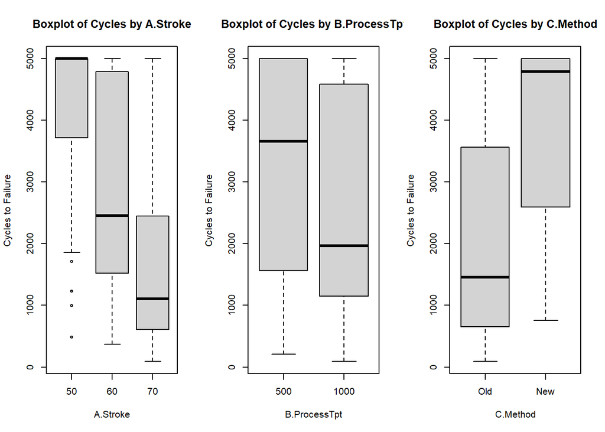

```r
par(mfrow = c(1, 3))
for (f in factor_names) {
  boxplot(Cycles ~ get(f),
          data = df,
          main = paste("Boxplot of Cycles by", f),
          xlab = f,
          ylab = "Cycles to Failure")
}
```

#### Observations:

- The distribution of the number of cycles to spring failure graphically indicate a strong effect of covariate A and C.
- Covariate B seems to have less influence on the failure rate.

### Linear “trending”

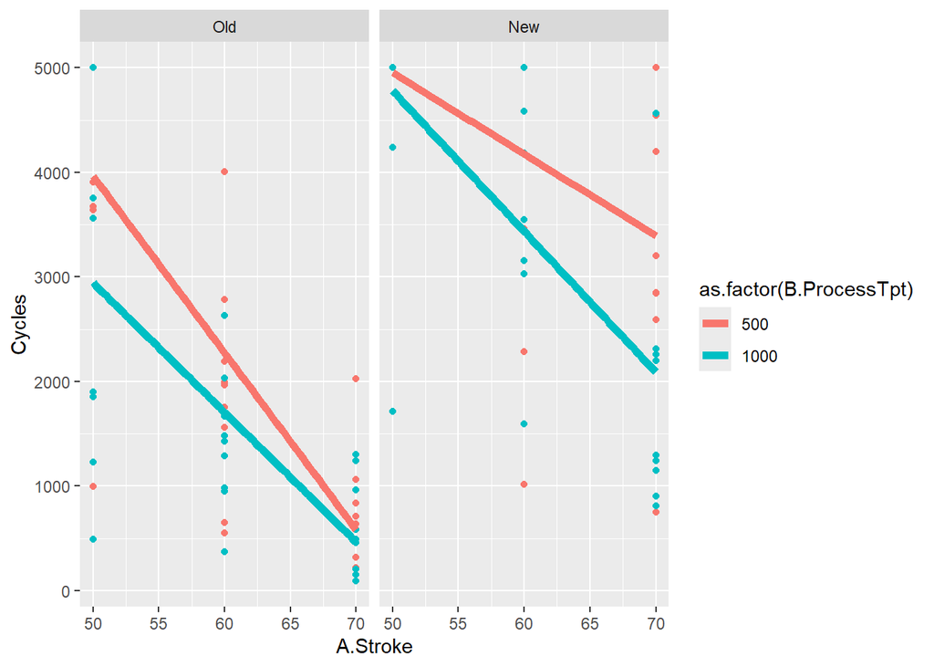

```r
# Plot 'Cycles' vs. 'A.Stroke'
# Visualize other factors as color or facets
print(ggplot(df, aes(x = A.Stroke, y = Cycles, colour = as.factor(B.ProcessTpt))) +
        geom_point() +
        geom_smooth(method = "lm", se = FALSE, linewidth = 2) +
        facet_wrap(~ C.Method)
      )
```

#### Observations:

- *ATTENTION*: Fitting a linear regression is only made for *informative / exploration purpose*. Censored data should not be modeled using linear regression models.
- Increasing A -> increasing failure rate
- Increasing B -> increasing failure rate
- New method (C) -> decreasing failure rate

## Survival Analysis

### Kaplan-Meir models [1 covariate at a time]

```
## [1] "-------- KM Survival model with covariate: A.Stroke --------"
##
## Call: survfit(formula = Surv(Cycles, Censoring) ~ get(f), data = df,
##     conf.type = "log-log")
##
##            n events median 0.95LCL 0.95UCL
## get(f)=50 36     12     NA    4241      NA
## get(f)=60 36     27   2458    1670    3545
## get(f)=70 36     34   1106     712    2029
##
## [1] "---------------------------------------------------------------"
```

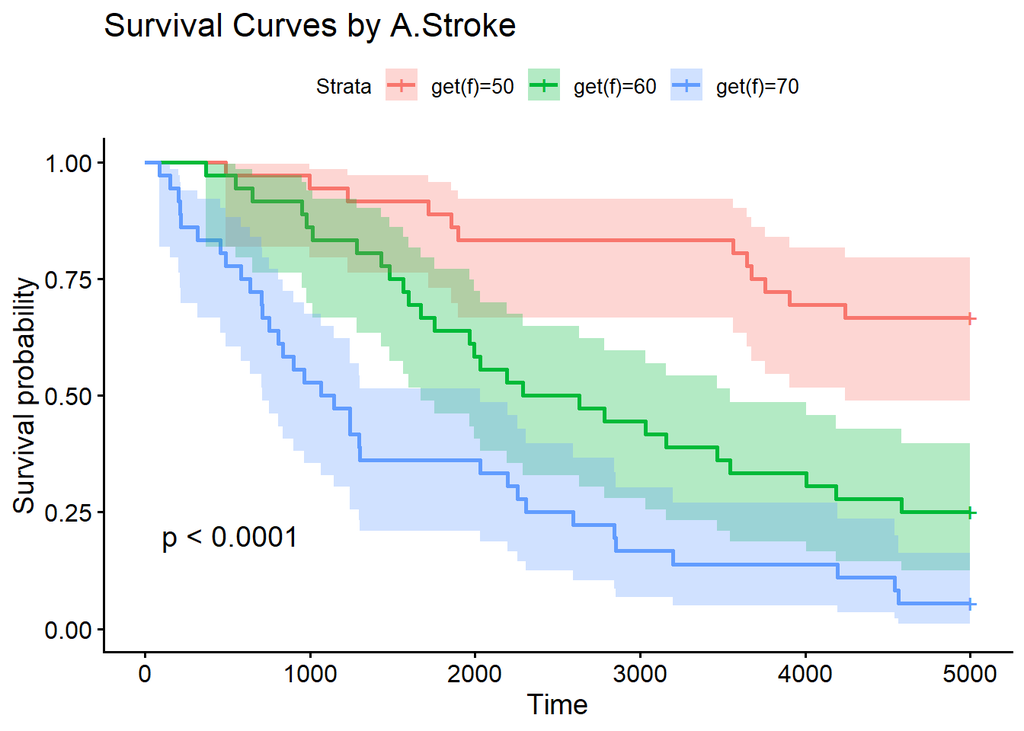

```
## [1] "-------- KM Survival model with covariate: B.ProcessTpt --------"
##
## Call: survfit(formula = Surv(Cycles, Censoring) ~ get(f), data = df,
##     conf.type = "log-log")
##
##              n events median 0.95LCL 0.95UCL
## get(f)=500  54     32   3659    2287      NA
## get(f)=1000 54     41   1964    1301    3158
##
## [1] "---------------------------------------------------------------"
```

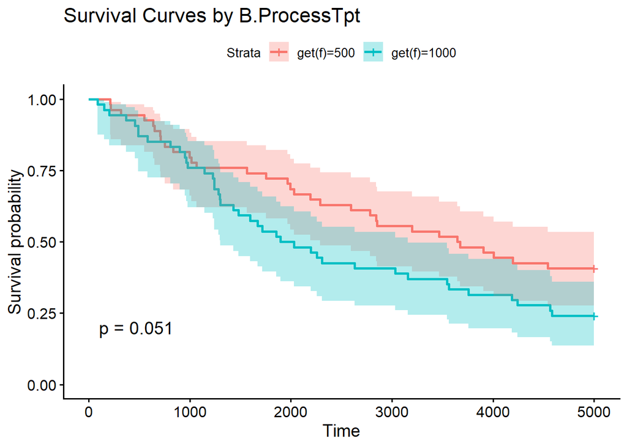

```
## [1] "-------- KM Survival model with covariate: C.Method --------"
##
## Call: survfit(formula = Surv(Cycles, Censoring) ~ get(f), data = df,
##     conf.type = "log-log")
##
##             n events median 0.95LCL 0.95UCL
## get(f)=Old 54     46   1455     980    1967
## get(f)=New 54     27   4583    3464      NA
##
## [1] "---------------------------------------------------------------"
```

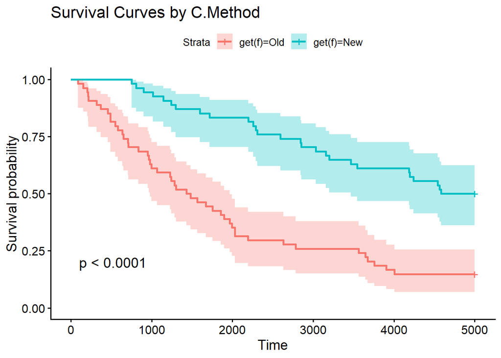

```r
# Fit Kaplan-Meier model for each covariate
for (f in factor_names) {
  fit.KM <- survfit(
    Surv(Cycles, Censoring) ~ get(f),
    data = df,
    conf.type = "log-log")

  print(paste0('-------- KM Survival model with covariate: ', f, ' --------'))
  cat('\n')

  print(fit.KM)

  cat('\n')
  print('---------------------------------------------------------------')
  cat('\n')

  # Plot the curves
  ggsurvplot(fit.KM, data = df,
             conf.int = TRUE,
             pval = TRUE,
             title = paste("Survival Curves by", f)) |> print()

}
```

#### Observations:

- A.Stroke and C.Method show significant differences (p < 0.001) in survival curves
- B.ProcessTpt shows less pronounced differences (p = 0.051)

### Logrank comparison tests [1 covariate at a time, with stratification]

```r
# Compare groups using Logrank or Fleming-Harrington tests
# For each factor, stratify by the other two factors to control for their effects

rho = 0 # 0 for Logrank, 1 for FH test

for (f in factor_names) {
  # 1. Identify which variables to stratify by
  strata_vars <- factor_names[factor_names != f]

  # 2. Build the formula string
  # Result looks like: "Surv(Cycles, Censoring) ~ A.Stroke + strata(B.ProcessTpt, C.Method)"
  strata_part <- paste0("strata(", paste(strata_vars, collapse = ", "), ")")
  formula_str <- paste0("Surv(Cycles, Censoring) ~ ", f, " + ", strata_part)

  print(paste0('-------- Testing Covariate: ', f, ' --------'))
  print(paste0('Formula: ', formula_str))

  # 3. Convert string to formula and run test
  test_result <- survdiff(as.formula(formula_str), data = df, rho = rho)

  print(test_result)
  cat('\n---------------------------------------------------\n\n')
}
```

```
## [1] "-------- Testing Covariate: A.Stroke --------"
## [1] "Formula: Surv(Cycles, Censoring) ~ A.Stroke + strata(B.ProcessTpt, C.Method)"
## Call:
## survdiff(formula = as.formula(formula_str), data = df, rho = rho)
##
##              N Observed Expected (O-E)^2/E (O-E)^2/V
## A.Stroke=50 36       12     37.7    17.495    40.871
## A.Stroke=60 36       27     24.2     0.312     0.486
## A.Stroke=70 36       34     11.1    47.417    62.100
##
##  Chisq= 75.3  on 2 degrees of freedom, p= <2e-16
##
## ---------------------------------------------------
##
## [1] "-------- Testing Covariate: B.ProcessTpt --------"
## [1] "Formula: Surv(Cycles, Censoring) ~ B.ProcessTpt + strata(A.Stroke, C.Method)"
## Call:
## survdiff(formula = as.formula(formula_str), data = df, rho = rho)
##
##                    N Observed Expected (O-E)^2/E (O-E)^2/V
## B.ProcessTpt=500  54       32     44.3      3.43       9.5
## B.ProcessTpt=1000 54       41     28.7      5.31       9.5
##
##  Chisq= 9.5  on 1 degrees of freedom, p= 0.002
##
## ---------------------------------------------------
##
## [1] "-------- Testing Covariate: C.Method --------"
## [1] "Formula: Surv(Cycles, Censoring) ~ C.Method + strata(A.Stroke, B.ProcessTpt)"
## Call:
## survdiff(formula = as.formula(formula_str), data = df, rho = rho)
##
##               N Observed Expected (O-E)^2/E (O-E)^2/V
## C.Method=Old 54       46       20      33.9      55.1
## C.Method=New 54       27       53      12.8      55.1
##
##  Chisq= 55.1  on 1 degrees of freedom, p= 1e-13
##
## ---------------------------------------------------
```

### Hazard functions at low vs. high levels of each covariate

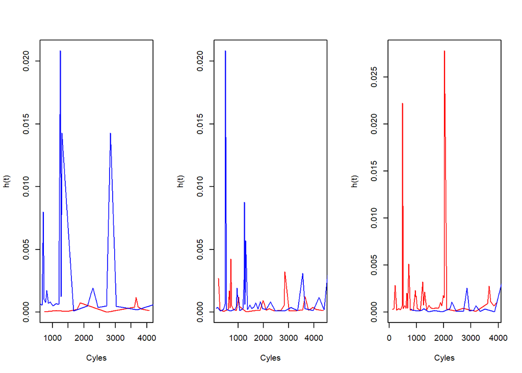

```r
par(mfrow = c(1, 3))

# Comparing A.Stroke = 50 vs. 70

haz_low <- with(subset(df, A.Stroke == 50), kphaz.fit(Cycles, Censoring))
haz_high <- with(subset(df, A.Stroke == 70), kphaz.fit(Cycles, Censoring))

plot(haz_low$time, haz_low$haz, type='l', col="red",
     xlab = 'Cyles',
     ylab = 'h(t)',
     ylim = c(0, max(haz_low$haz, haz_high$haz))
     )
lines(haz_high$time, haz_high$haz, col="blue")

# Comparing B.ProcessTpt = 500 vs. 1000

haz_low <- with(subset(df, B.ProcessTpt == 500), kphaz.fit(Cycles, Censoring))
haz_high <- with(subset(df, B.ProcessTpt == 1000), kphaz.fit(Cycles, Censoring))

plot(haz_low$time, haz_low$haz, type='l', col="red",
     xlab = 'Cyles',
     ylab = 'h(t)',
     ylim = c(0, max(haz_low$haz, haz_high$haz))
     )
lines(haz_high$time, haz_high$haz, col="blue")

# Comparing two groups C.Method = Old vs. New

haz_low <- with(subset(df, C.Method == "Old"), kphaz.fit(Cycles, Censoring))
haz_high <- with(subset(df, C.Method == "New"), kphaz.fit(Cycles, Censoring))

plot(haz_low$time, haz_low$haz, type='l', col="red",
     xlab = 'Cyles',
     ylab = 'h(t)',
     ylim = c(0, max(haz_low$haz, haz_high$haz))
     )
lines(haz_high$time, haz_high$haz, col="blue")
```

### Cox Proportional Hazard (CPH) modelling

```r
# Model with main effects and the interaction between Stroke and Method
fit.cph_full <- coxph(
  Surv(Cycles, Censoring) ~ A.Stroke + B.ProcessTpt + C.Method +
    A.Stroke * B.ProcessTpt + A.Stroke * C.Method + B.ProcessTpt * C.Method,
  data = df)
summary(fit.cph_full)
```

```
## Call:
## coxph(formula = Surv(Cycles, Censoring) ~ A.Stroke + B.ProcessTpt +
##     C.Method + A.Stroke * B.ProcessTpt + A.Stroke * C.Method +
##     B.ProcessTpt * C.Method, data = df)
##
##   n= 108, number of events= 73
##
##                                coef  exp(coef)   se(coef)      z Pr(>|z|)
## A.Stroke                  1.920e-01  1.212e+00  5.517e-02  3.481   0.0005 ***
## B.ProcessTpt              3.405e-03  1.003e+00  4.096e-03  0.831   0.4058
## C.MethodNew              -2.610e+00  7.354e-02  2.675e+00 -0.975   0.3293
## A.Stroke:B.ProcessTpt    -3.809e-05  1.000e+00  6.576e-05 -0.579   0.5624
## A.Stroke:C.MethodNew     -1.131e-02  9.887e-01  3.701e-02 -0.306   0.7598
## B.ProcessTpt:C.MethodNew  1.400e-03  1.001e+00  1.059e-03  1.323   0.1860
## ---
## Signif. codes:  0 '***' 0.001 '**' 0.01 '*' 0.05 '.' 0.1 ' ' 1
##
##                          exp(coef) exp(-coef) lower .95 upper .95
## A.Stroke                   1.21170     0.8253 1.0875205     1.350
## B.ProcessTpt               1.00341     0.9966 0.9953870     1.011
## C.MethodNew                0.07354    13.5973 0.0003883    13.929
## A.Stroke:B.ProcessTpt      0.99996     1.0000 0.9998330     1.000
## A.Stroke:C.MethodNew       0.98875     1.0114 0.9195631     1.063
## B.ProcessTpt:C.MethodNew   1.00140     0.9986 0.9993253     1.003
##
## Concordance= 0.826  (se = 0.022 )
## Likelihood ratio test= 109.3  on 6 df,   p=<2e-16
## Wald test            = 85.92  on 6 df,   p=<2e-16
## Score (logrank) test = 136.2  on 6 df,   p=<2e-16
```

##### Observations:

- Full model with all main effects and interactions shows that A.Stroke is significant (p < 0.01)
- Model needs to be simplified

### CPH Model selection with AIC selection using step() function

```r
# Perform model selection based on AIC
fit.cph_selected <- step(fit.cph_full, direction = "both", trace = 2)
```

```
## Start:  AIC=520.28
## Surv(Cycles, Censoring) ~ A.Stroke + B.ProcessTpt + C.Method +
##     A.Stroke * B.ProcessTpt + A.Stroke * C.Method + B.ProcessTpt *
##     C.Method
##
## trying -A.Stroke:B.ProcessTpt
## trying -A.Stroke:C.Method
## trying -B.ProcessTpt:C.Method
##                         Df    AIC
## - A.Stroke:C.Method      1 518.37
## - A.Stroke:B.ProcessTpt  1 518.62
## - B.ProcessTpt:C.Method  1 520.07
## <none>                     520.28
##
## Step:  AIC=518.37
## Surv(Cycles, Censoring) ~ A.Stroke + B.ProcessTpt + C.Method +
##     A.Stroke:B.ProcessTpt + B.ProcessTpt:C.Method
##
## trying -A.Stroke:B.ProcessTpt
## trying -B.ProcessTpt:C.Method
## trying +A.Stroke:C.Method
##                         Df    AIC
## - A.Stroke:B.ProcessTpt  1 516.78
## <none>                     518.37
## - B.ProcessTpt:C.Method  1 518.38
## + A.Stroke:C.Method      1 520.28
##
## Step:  AIC=516.78
## Surv(Cycles, Censoring) ~ A.Stroke + B.ProcessTpt + C.Method +
##     B.ProcessTpt:C.Method
##
## trying -A.Stroke
## trying -B.ProcessTpt:C.Method
## trying +A.Stroke:B.ProcessTpt
## trying +A.Stroke:C.Method
##                         Df    AIC
## - B.ProcessTpt:C.Method  1 516.43
## <none>                     516.78
## + A.Stroke:B.ProcessTpt  1 518.37
## + A.Stroke:C.Method      1 518.62
## - A.Stroke               1 593.74
##
## Step:  AIC=516.43
## Surv(Cycles, Censoring) ~ A.Stroke + B.ProcessTpt + C.Method
##
## trying -A.Stroke
## trying -B.ProcessTpt
## trying -C.Method
## trying +A.Stroke:B.ProcessTpt
## trying +A.Stroke:C.Method
## trying +B.ProcessTpt:C.Method
##                         Df    AIC
## <none>                     516.43
## + B.ProcessTpt:C.Method  1 516.78
## + A.Stroke:C.Method      1 518.13
## + A.Stroke:B.ProcessTpt  1 518.38
## - B.ProcessTpt           1 524.23
## - C.Method               1 574.75
## - A.Stroke               1 592.18
```

```r
# Display the summary of the selected model
summary(fit.cph_selected)
```

```
## Call:
## coxph(formula = Surv(Cycles, Censoring) ~ A.Stroke + B.ProcessTpt +
##     C.Method, data = df)
##
##   n= 108, number of events= 73
##
##                    coef  exp(coef)   se(coef)      z Pr(>|z|)
## A.Stroke      0.1560588  1.1688950  0.0189474  8.236  < 2e-16 ***
## B.ProcessTpt  0.0015174  1.0015186  0.0004875  3.112  0.00186 **
## C.MethodNew  -2.2037530  0.1103881  0.3021754 -7.293 3.03e-13 ***
## ---
## Signif. codes:  0 '***' 0.001 '**' 0.01 '*' 0.05 '.' 0.1 ' ' 1
##
##              exp(coef) exp(-coef) lower .95 upper .95
## A.Stroke        1.1689     0.8555   1.12628    1.2131
## B.ProcessTpt    1.0015     0.9985   1.00056    1.0025
## C.MethodNew     0.1104     9.0589   0.06105    0.1996
##
## Concordance= 0.826  (se = 0.022 )
## Likelihood ratio test= 107.2  on 3 df,   p=<2e-16
## Wald test            = 84.98  on 3 df,   p=<2e-16
## Score (logrank) test = 97.9  on 3 df,   p=<2e-16
```

### Checking CPH assumption: Martingale residuals

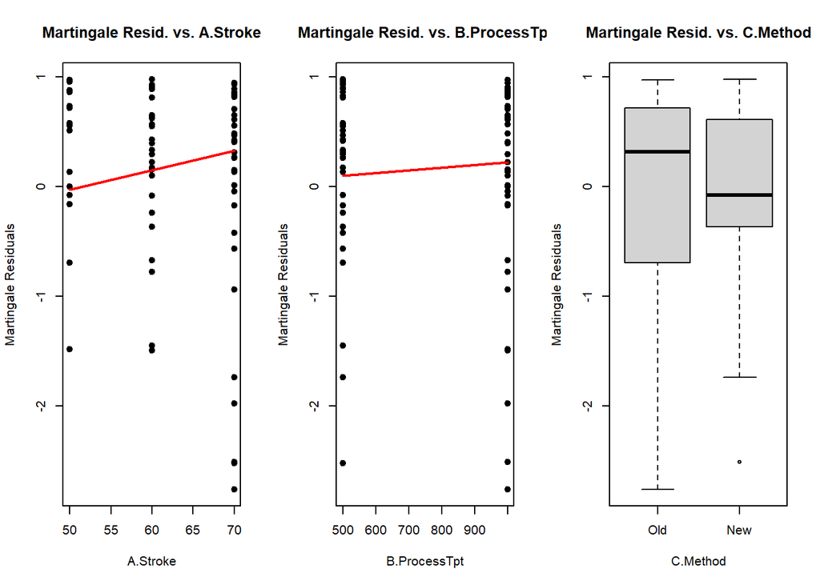

```r
# Martingale residuals for the selected model
df$Resid.Martingale <- residuals(fit.cph_selected, type = "martingale")

# plot residuals vs factors
par(mfrow = c(1, 3))

with(df, {
  plot(A.Stroke, Resid.Martingale,
       xlab = "A.Stroke",
       ylab = "Martingale Residuals",
       main = "Martingale Resid. vs. A.Stroke",
       pch = 19 , col = 'black')
  lines(lowess(A.Stroke, Resid.Martingale), col = "red", lw = 2)

  plot(B.ProcessTpt, Resid.Martingale,
       xlab = "B.ProcessTpt",
       ylab = "Martingale Residuals",
       main = "Martingale Resid. vs. B.ProcessTpt",
       pch = 19 , col = 'black')
  lines(lowess(B.ProcessTpt, Resid.Martingale), col = "red", lw = 2)

  plot(C.Method, Resid.Martingale,
       xlab = "C.Method",
       ylab = "Martingale Residuals",
       main = "Martingale Resid. vs. C.Method")
})
```

#### Observations:

- A and B used as numeric covariates in the model (although tested at discrete levels) and C used as categorical covariate.
- Martingale residuals do not show any clear pattern when plotted against covariates.
- Functional form of the covariates is correctly specified in the model.

### Checking CPH assumption: Deletion residuals (DFBETAS)

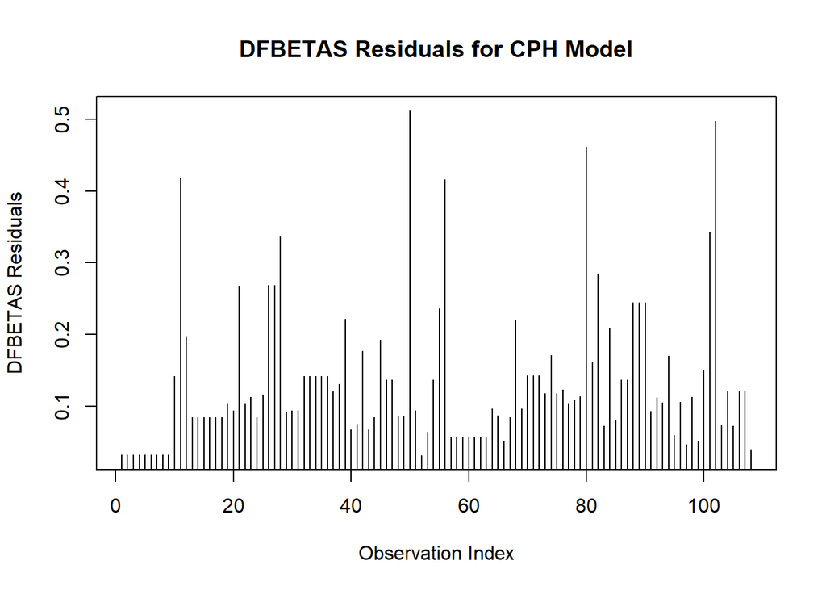

```r
# Residuals with deletion
df$Resid.DFBETAS <- sqrt(rowSums(residuals(fit.cph_selected, type = "dfbetas")^2))

# Plot
plot(df$Resid.DFBETAS, type = "h",
     xlab = "Observation Index",
     ylab = "DFBETAS Residuals",
     main = "DFBETAS Residuals for CPH Model")
abline(h = 0, col = "red")
```

#### Observations:

- No observation has a DFBETAS residual that stands out as an influential outlier.

### Checking CPH assumption: Proportionality of hazards (log-log plots)

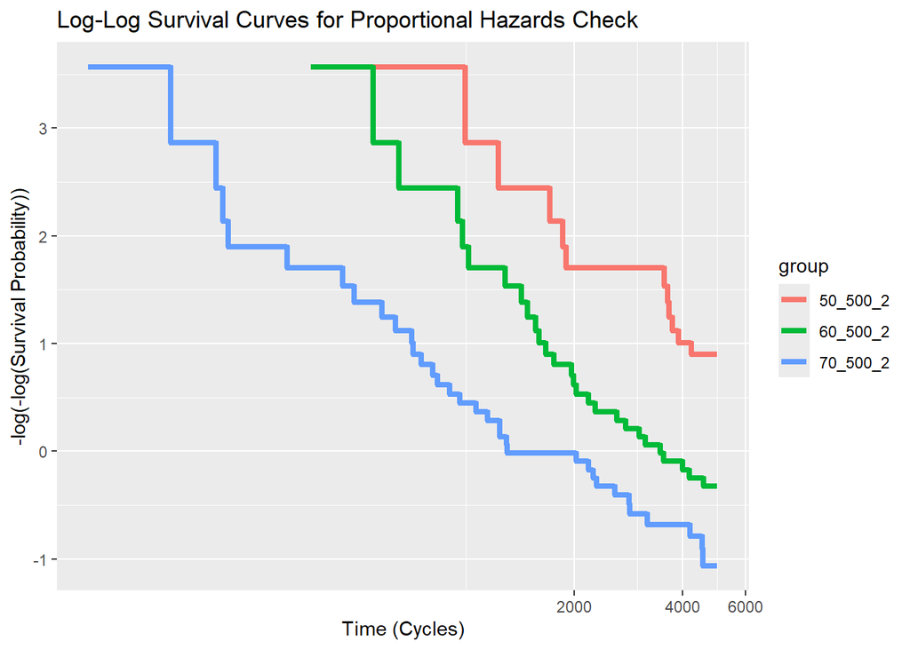

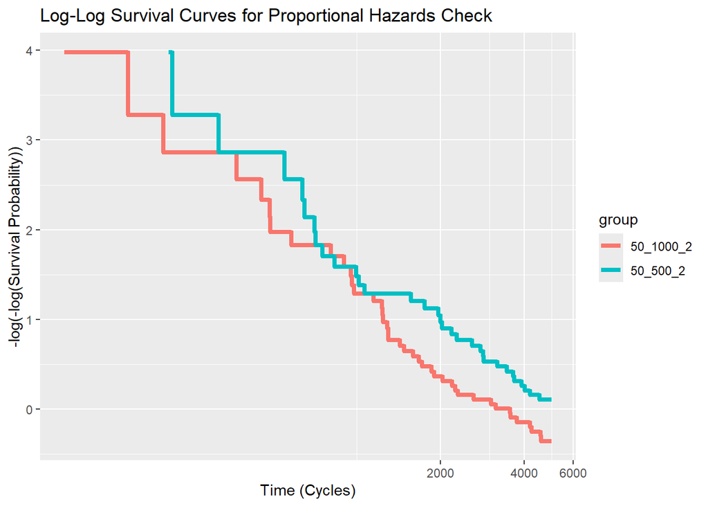

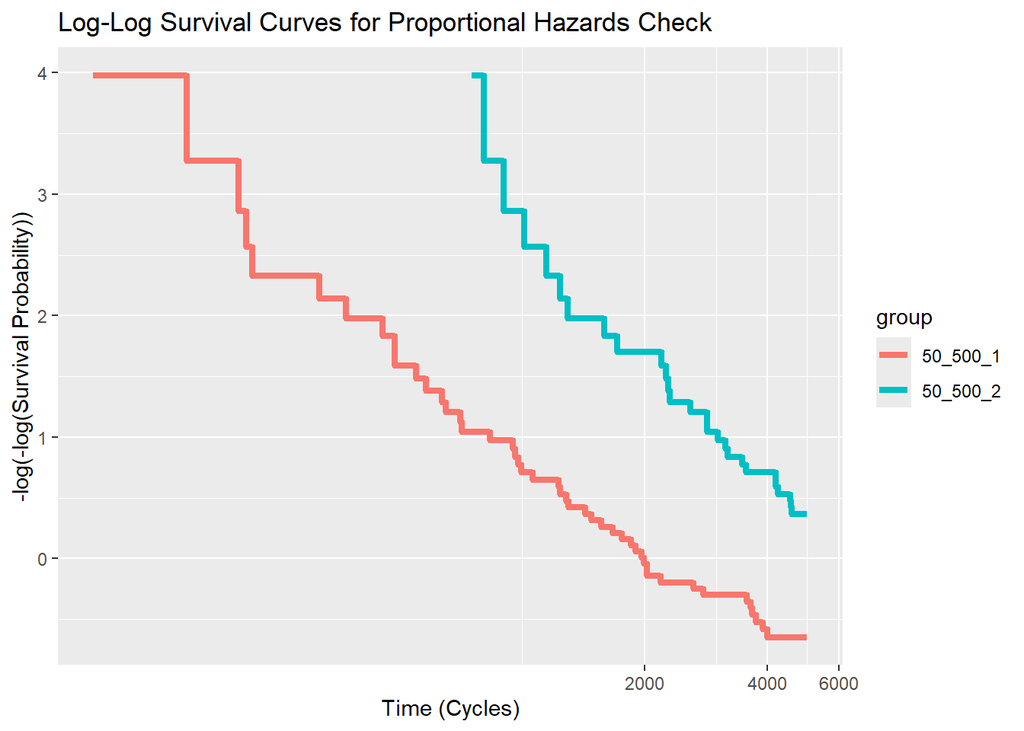

```r
# Proportionality of hazards log-log plots
for (f in factor_names) {
  surv = ddply(df,
               f,
               function(subdf) {
                 fit <- survfit(Surv(Cycles, Censoring) ~ 1, data = subdf)
                 data.frame(
                   time = fit$time,
                   surv = fit$surv,
                   group = paste(subdf[1, factor_names], collapse = "_"))
                 })

  print(ggplot(surv, aes(x = time, y = -log(-log(surv)), color = group)) +
          geom_step(linewidth = 1.5) +
          coord_trans(x = "log", y = "identity") +
          labs(title = "Log-Log Survival Curves for Proportional Hazards Check",
               x = "Time (Cycles)",
               y = "-log(-log(Survival Probability))"))
}
```

### Checking CPH assumption: Schoenfeld residuals

```r
# Check proportional hazards assumption
residual.Schoenfeld <- cox.zph(fit.cph_selected)
print(residual.Schoenfeld)
```

```
##               chisq df    p
## A.Stroke     0.0923  1 0.76
## B.ProcessTpt 0.5749  1 0.45
## C.Method     0.3439  1 0.56
## GLOBAL       0.9118  3 0.82
```

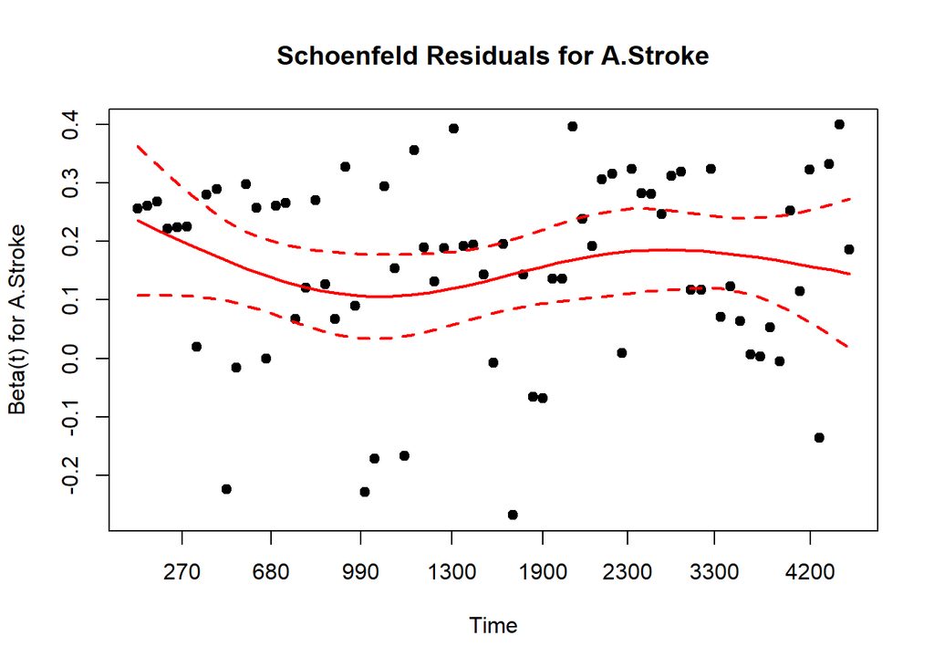

```r
# Residuals vs. Time (Cycles) for each covariate
plot(residual.Schoenfeld,
     var = "A.Stroke",
     main = "Schoenfeld Residuals for A.Stroke",
     pch = 19 , col = 'red', lw = 2)
```

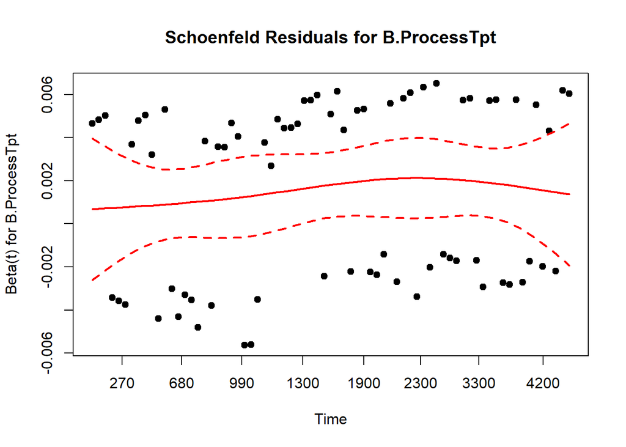

```r
plot(residual.Schoenfeld,
     var = "B.ProcessTpt",
     main = "Schoenfeld Residuals for B.ProcessTpt",
     pch = 19 , col = 'red', lw = 2)
```

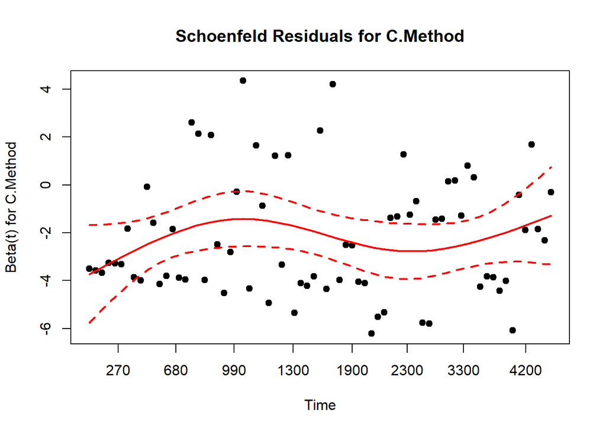

```r
plot(residual.Schoenfeld,
     var = "C.Method",
     main = "Schoenfeld Residuals for C.Method",
     pch = 19 , col = 'red', lw = 2)
```

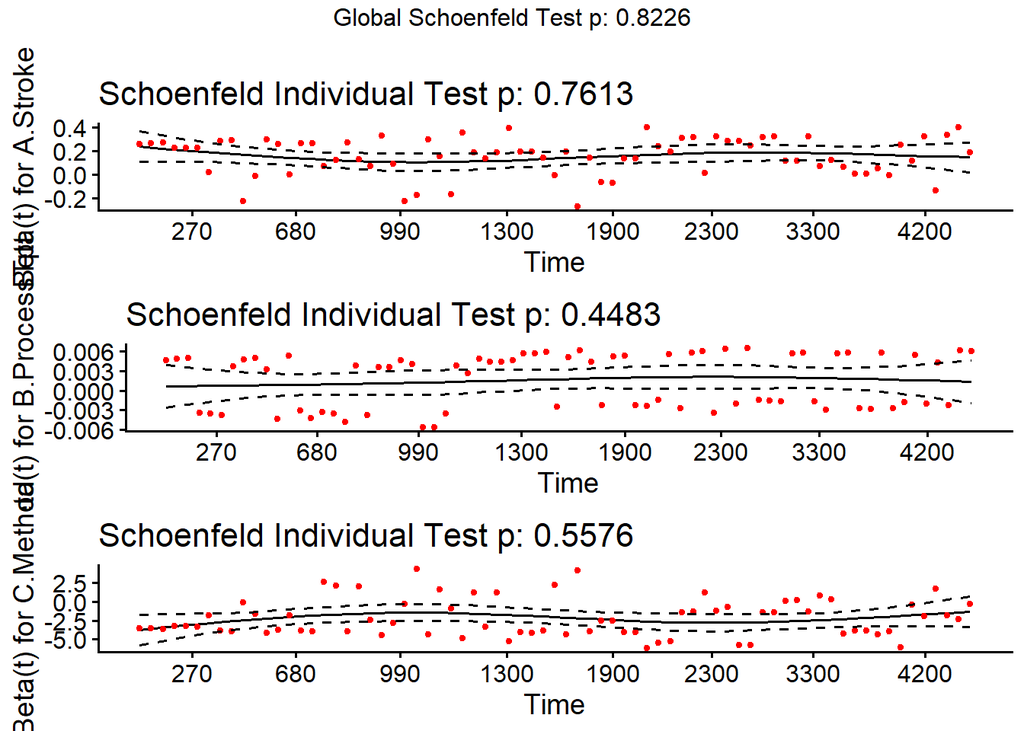

```r
ggcoxzph(residual.Schoenfeld)
```

#### Observations:

- The global and each covariate tests for proportional hazards assumption are not statistically significant (p > 0.05), suggesting that the covariate effects are constant over time.
- Schoenfeld residual plots vs. Time (Cycles) shows an approximately flat smoothed lines for each covariate, further supporting the proportional hazards assumption.